# Test a Perceptual Phenomenon

### Analyzing the Stroop Effect

Perform the analysis in the space below. Remember to follow [the instructions](https://docs.google.com/document/d/1-OkpZLjG_kX9J6LIQ5IltsqMzVWjh36QpnP2RYpVdPU/pub?embedded=True) and review the [project rubric](https://review.udacity.com/#!/rubrics/71/view) before submitting. Once you've completed the analysis and write-up, download this file as a PDF or HTML file, upload that PDF/HTML into the workspace here (click on the orange Jupyter icon in the upper left then Upload), then use the Submit Project button at the bottom of this page. This will create a zip file containing both this .ipynb doc and the PDF/HTML doc that will be submitted for your project.

(1) What is the independent variable? What is the dependent variable?

Independent variable: congruent or incongruent  
Dependent variable: response time in seconds

(2) What is an appropriate set of hypotheses for this task? Specify your null and alternative hypotheses, and clearly define any notation used. Justify your choices.

2a) Establish hypotheses:

##### Hypotheses:

H0: ( μi - μc = 0 ) There is no significant difference in the population average response time between congruent or incongrent.

H1: ( μi - μc ≠ 0 ) There is a significant difference in the population average response times.

##### Notations:

H0 = Null Hypothesis  
μc = The mean of the Congruent population's response times.  
μi = The mean of the Incongruent population's response times.  
H1 = Alternate Hypothesis

2b) Establish a statistical test:

A two-tailed, paired sample t-test should be used. This is becuase we have less than 30 samples for both the congruent and incongruent groups and we do not know the true population mean or standard deviation. In addition each group of participants have been tested twice.

#### (3)

Report some descriptive statistics regarding this dataset. Include at least one measure of central tendency and at least one measure of variability. The name of the data file is 'stroopdata.csv'.

```python
# Perform the analysis here
```

```python
import pandas as pd
import numpy as np
import random
import matplotlib.pyplot as plt
import scipy
from scipy import stats
import statsmodels.api as sm

#import the dataset and show the first 5 rows
df = pd.read_csv('stroopdata.csv')
df.head()
```

|  | Congruent | Incongruent |
| --- | --- | --- |
| 0 | 12.079 | 19.278 |
| 1 | 16.791 | 18.741 |
| 2 | 9.564 | 21.214 |
| 3 | 8.630 | 15.687 |
| 4 | 14.669 | 22.803 |

```python
#measure a central tendency of each independent variable
mean_c = df['Congruent'].mean()
mean_i = df['Incongruent'].mean()
mean_c, mean_i
```

```
(14.051124999999999, 22.015916666666666)
```

```python
#measure of variability
stdev_c = df['Congruent'].std()
stdev_i = df['Incongruent'].std()
stdev_c, stdev_i
```

```
(3.5593579576451955, 4.7970571224691376)
```

(4) Provide one or two visualizations that show the distribution of the sample data. Write one or two sentences noting what you observe about the plot or plots.

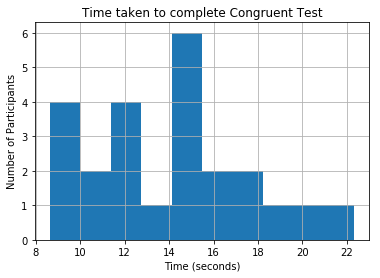

```python
# Build the visualizations here
df['Congruent'].hist()
plt.xlabel('Time (seconds)')
plt.ylabel('Number of Participants')
plt.title('Time taken to complete Congruent Test');
```

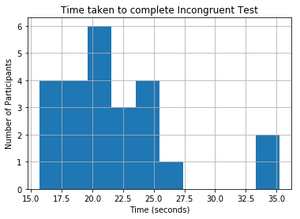

```python
df['Incongruent'].hist()
plt.xlabel('Time (seconds)')
plt.ylabel('Number of Participants')
plt.title('Time taken to complete Incongruent Test');
```

This histogram shows that the largest number of participants (6) took around 20 seconds to complete the incongruent test. The histogram appears to be right-skewed because two participants took longer than 33 seconds to complete the test. However, these participants could be considered outliers, since the majority of the particpents scored between 16 and 27 seconds.

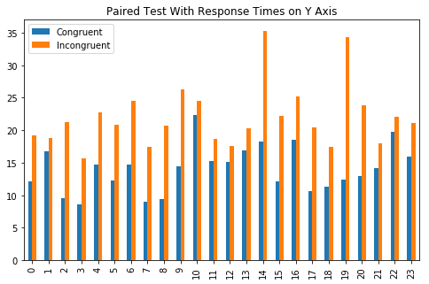

```python
df.plot(figsize=(8, 5), title='Paired Test With Response Times on Y Axis', kind='bar');
```

This bar chart shows that particpants took longer to name the ink colors of the incongruent test than the congruent test. There are no participants that took more time to complete the congruent test than the incongruent test.

(5) Now, perform the statistical test and report your results. What is your confidence level or Type I error associated with your test? What is your conclusion regarding the hypotheses you set up? Did the results match up with your expectations? **Hint:** Think about what is being measured on each individual, and what statistic best captures how an individual reacts in each environment.

The confidence level is 95% for the two-tailed paired t-test. And the degrees of freedom is 23 since the sample size is 24.

```python
#finding t-critical value for a 95% confidence level and 23 d.f.
stats.t.ppf(.95, 23)
```

```
1.7138715277470473
```

```python
# Perform the statistical test here
stats.ttest_rel(df['Congruent'], df['Incongruent'])
```

```
Ttest_relResult(statistic=-8.020706944109957, pvalue=4.1030005857111781e-08)
```

Additionally the p-value is less that the signaficance level of 0.05. Therefore, we can reject our null hypothesis. And we can condlude that the response times between the two groups are significatnly different. The results obseverd here match up with my expectations that the response times would take longer for the incongruent group to complete the test.

(6) Optional: What do you think is responsible for the effects observed? Can you think of an alternative or similar task that would result in a similar effect? Some research about the problem will be helpful for thinking about these two questions!